# hw1

B02612026_劉家文

2017/3/6

## 【為什麼會做這個題目？】

前陣子在新聞媒體上出現台大學生的宿舍自殺事件以及虐貓事件，他們觸發我想探索台大1980-2014輔導中心輔導人士統計數據，希望從30多年間不同諮詢項目使用人數/人次的變化，結合網路上挖掘到新聞、台大心輔中心的改革紀事做一些推測與提問。  
注：資料來源為台大主計處

## 【啊，圖表中的ABCDE是什麼意思?】

圖表中ABCDE表示心輔中心提供的不同服務項目，會以ABCDE表示是因為減緩字數過多造成的閱讀壓力，同時R在MAC運行無法讀主中文，因此採用ABCDE代稱。  
注：內容改寫自心輔中心網頁

### A.個別諮商‧晤談

輔導中心有臨床心理師及諮商心理師聆聽學生心聲、協助澄清迷惑、重新找到力量做自己及解決困境的方法；並遵守心理師專業倫理守則，同學們的心聲疑惑、測驗資料等，均在保密範圍內下進行。  
###B.測驗解釋  
經由輔導老師對測驗結果的分析與解釋，將有助於你面對改變和抉擇時做參考。不管你是想轉系、不知道該找什麼樣的工作、對自己的生涯感到困惑、想改善自己的人際關係、想更瞭解自己…等等，測驗都可以提供你面對改變與抉擇時的一種參考，再透過與中心專業諮商老師的協助與討論下，讓你了解自己的需要、釐清自己的興趣、想法、情緒、人際交往模式等，讓生命有一個新的可能性與新的開始！

### C.心理測驗

輔導中心所提供的測驗包括性格、職業興趣、個人興趣、智力及性向測驗等；心理測驗不是算命、也不是考試，它的功能在於幫助我們了解作測驗者目前的狀況。

### D.團體

團體就像一個現實的小世界，來參加團體的人，都有一個共同的目標—例如：肯定自己、解除壓力、人際關係、生涯探索者、考試焦慮、情感探索…..等等，在彼此的相互幫忙與支持下，團體中的彼此可學習在相互支持中成長， 解決人生習題。

### E.身心健康普查

於每學年度初對大一和轉學生新生實施問卷調查，建立同學身心的基本資料，並主動輔導需要的同學。

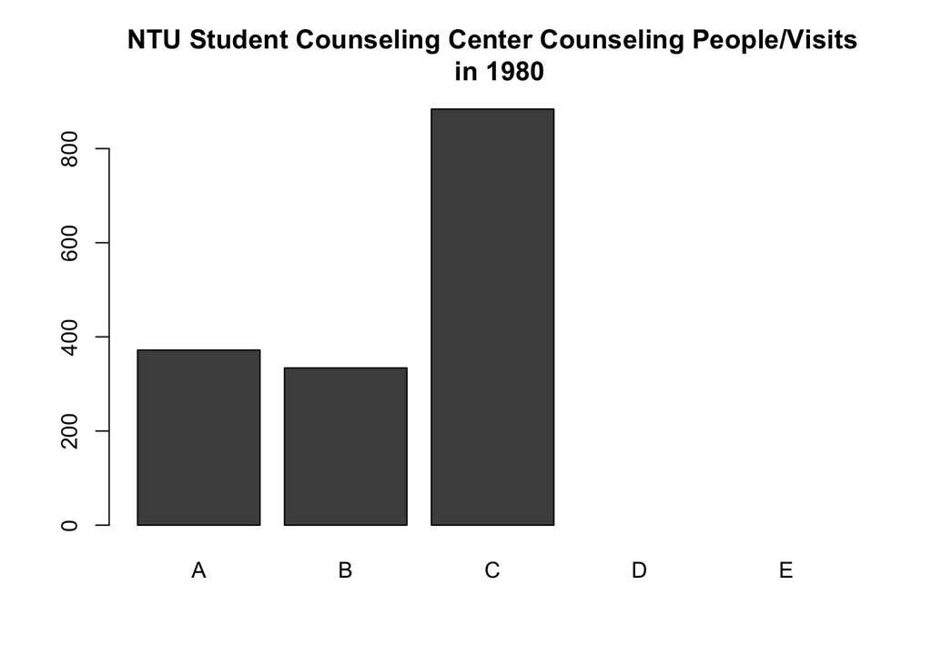

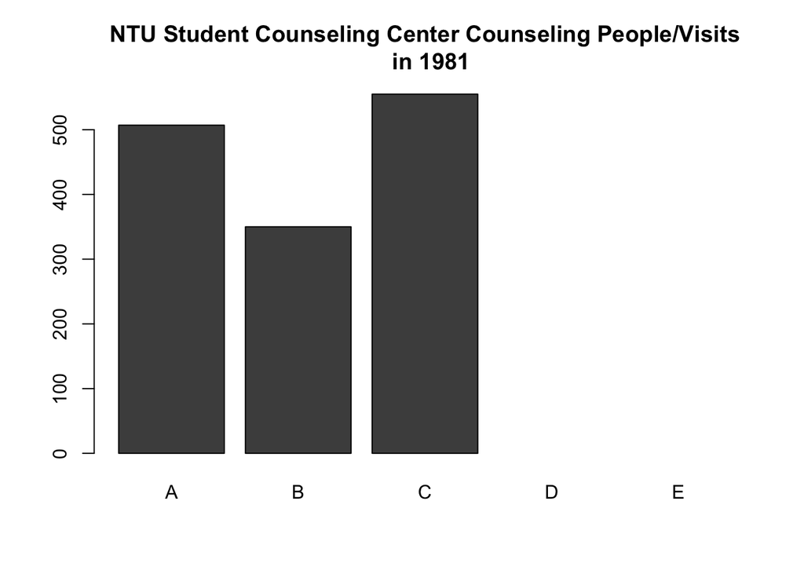

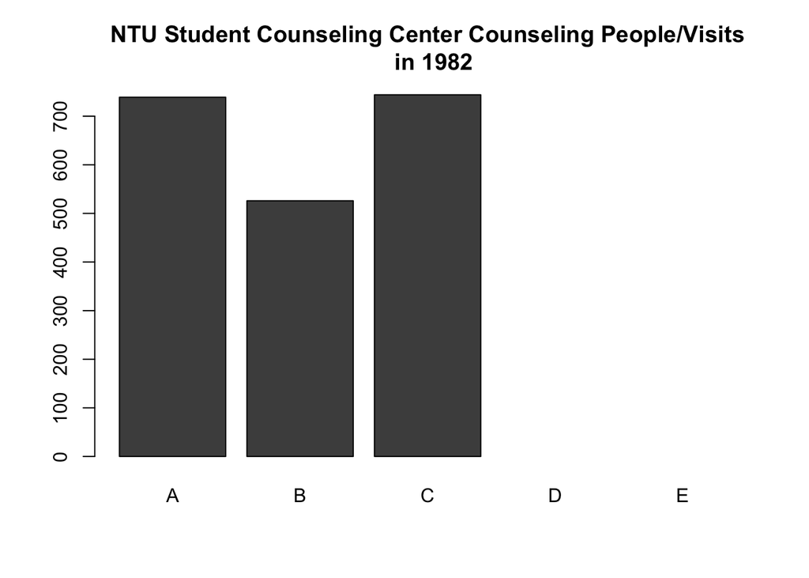

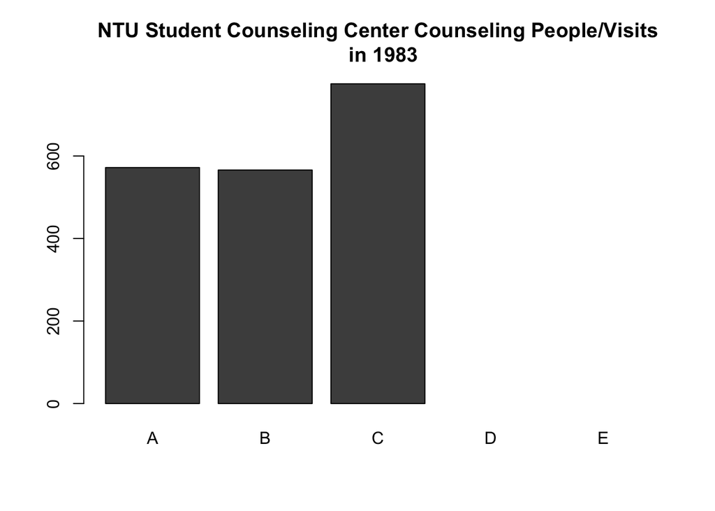

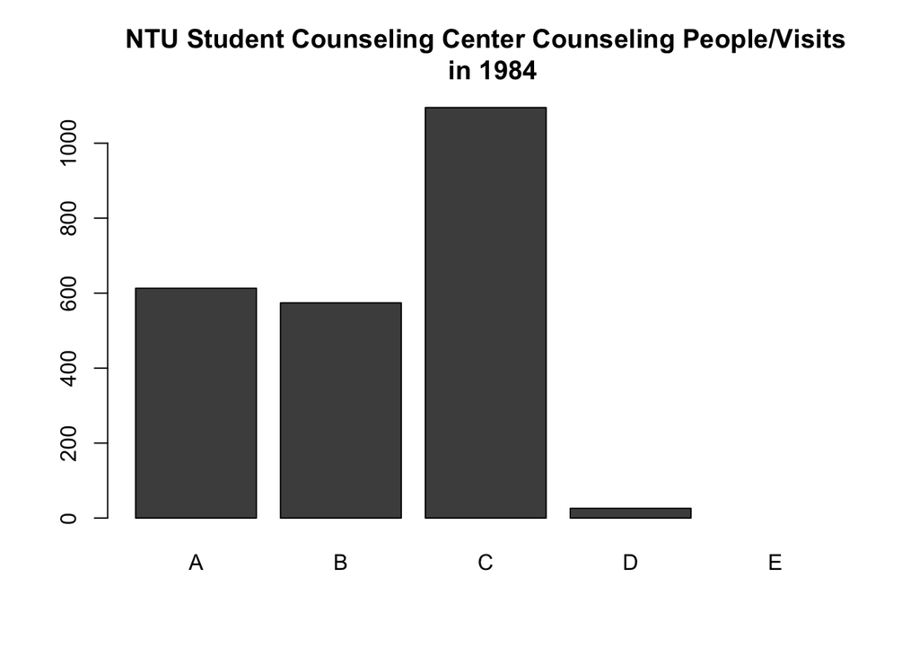

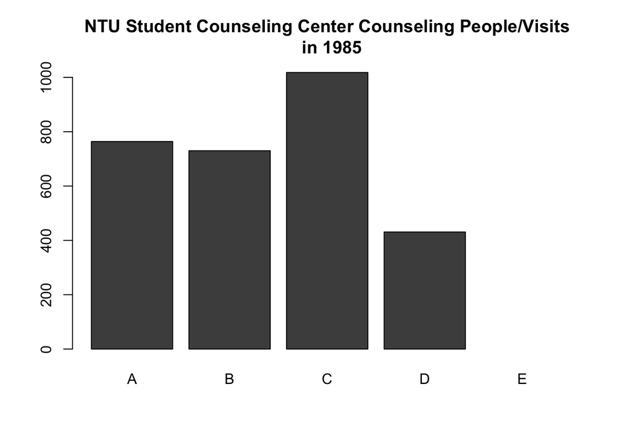

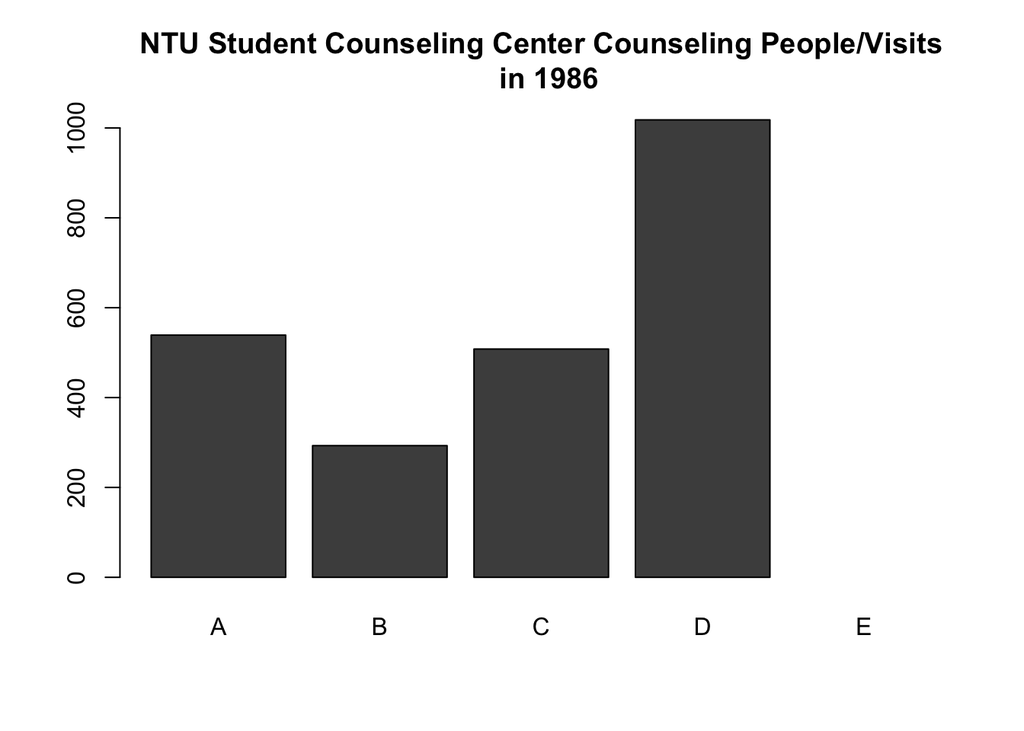

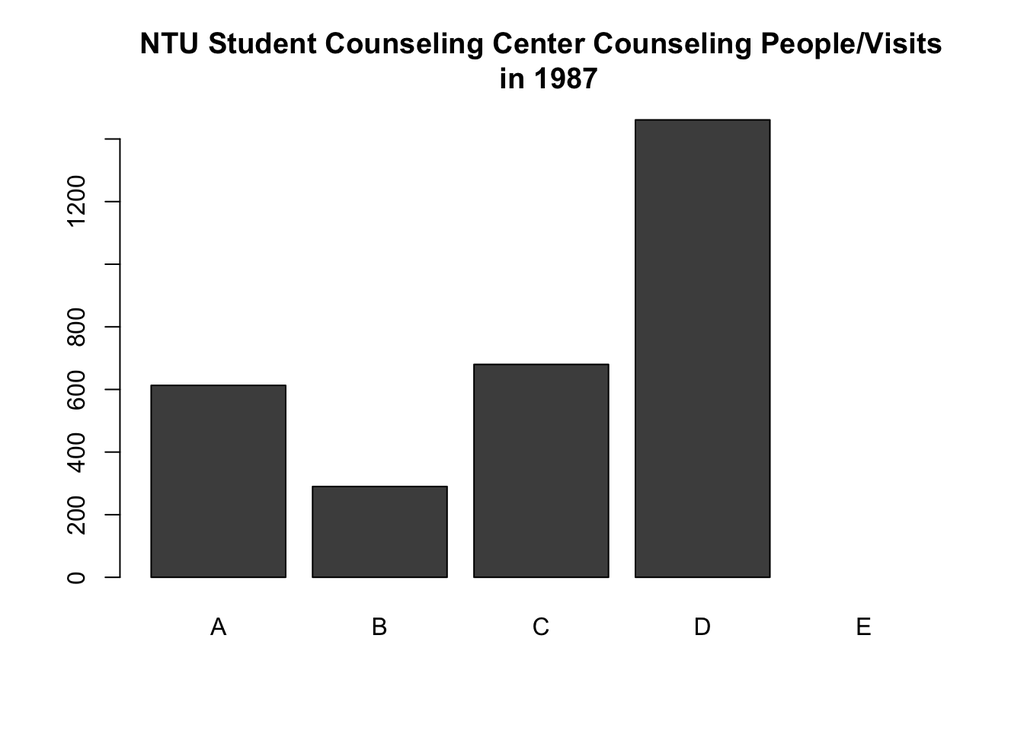

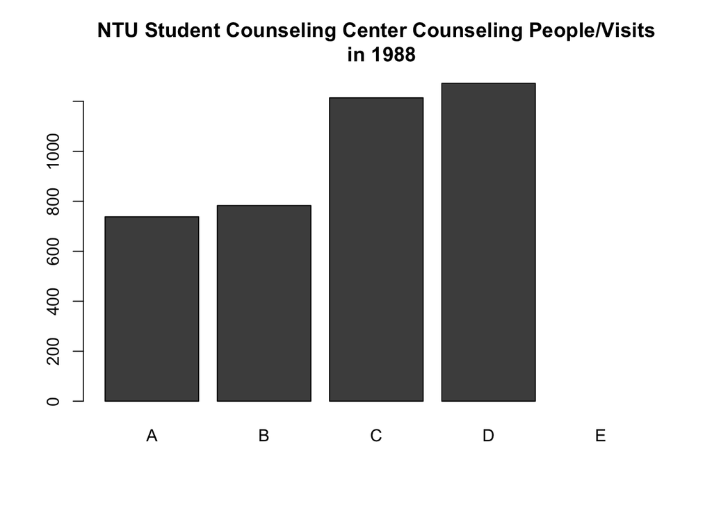

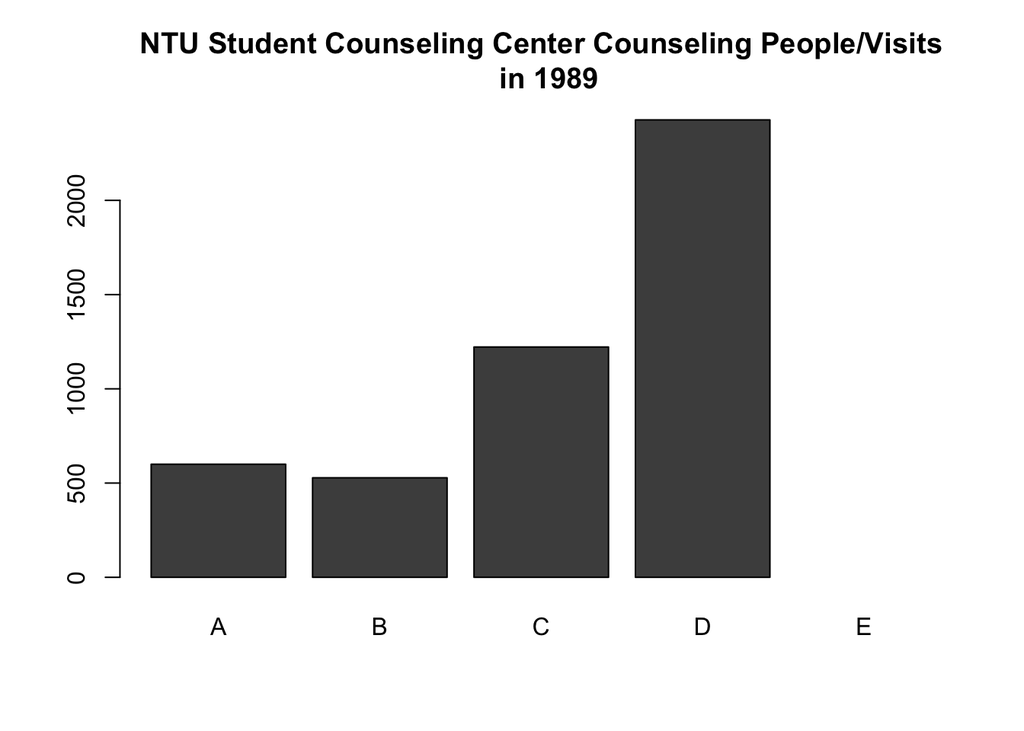

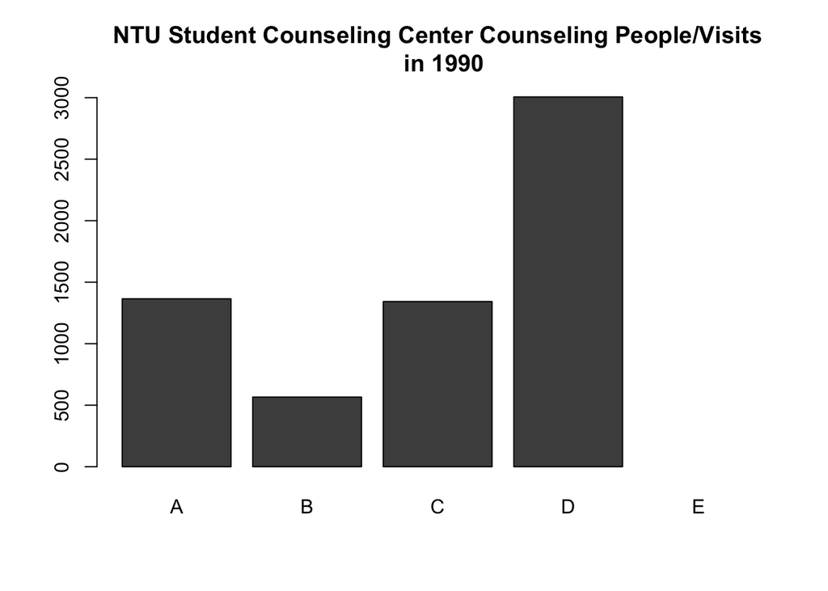

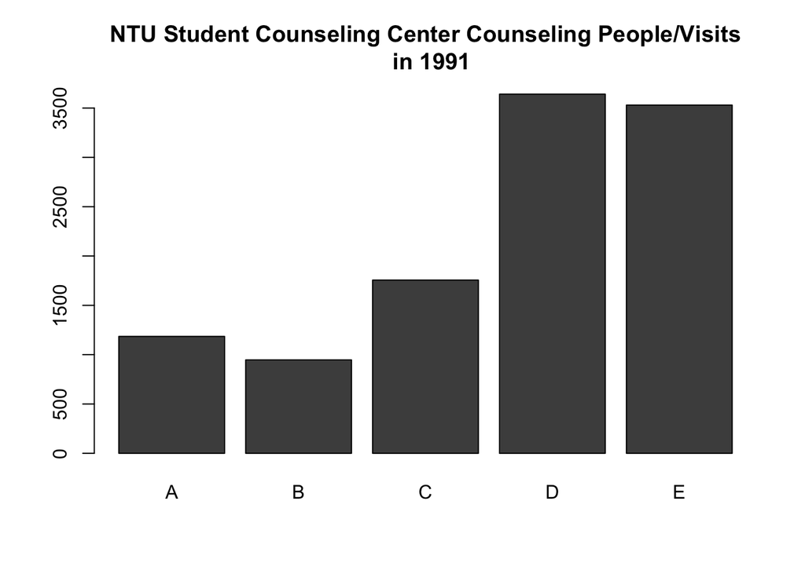

[23 more figures not shown]

```r
rm(list = ls(all=TRUE ))
library(png)
library(animation)

rawData=read.csv('hw1.csv',header =TRUE)

allLine=length(rawData[,1])
rawData=rawData[-allLine,]

yearid=rawData[,1]

for (yid in c(1:length(rawData[,1])))
{
  barplot(as.matrix(rawData[yid,c(-1)]),
          main = paste0("NTU Student Counseling Center Counseling People/Visits
 "," in ",rawData[yid,1]))
}
```

## 【從數據中發現了什麼？】

### 針對五個項目進行觀察，觀察要點為以下兩項：

1.極端值：最大最小值或者區間。  
2.極端數據變化：突增驟降。

### A.有關個別諮商‧晤談

1.極端值：個別諮商‧晤談在2014年產生高峰，使用人次是35年來最多，多達7,192人。  
2.極端數據變化：：1989-1990，參與個別諮商‧晤談者變為將近兩倍。

### B.有關測驗解釋

1.極端值：2014最少，使用人次數僅83人。  
2.極端數據變化：1993-1996連續四年超過1000人，其餘年份測驗解釋都少於1000。

### C.有關心理測驗

極端數據變化：1993-1996此連續四年是歷年人次最多的前四名，剛好跟測驗解釋的狀況一致。

### D.有關團體

發現兩段高峰  
1.高峰一：1992-1996  
1992-1996連續五年使用人次維持4000-7000，為一使用高峰；但一到1997，使用人次瞬間變為前年的約1/7。  
2.高峰二：2003-2006  
2002-2003使用人數變為將近兩倍，從3995-7556，接下來連續四年2003-2006，使用人數維持5000-7000，為另一使用高峰：但一到2007，使用人次從5365又驟降為1707。

### E.有關身心健康普查

1991年才開始有數據，推測是1991年猜開始實施身心健康普查。

## 【針對近年節節攀升的個別諮商‧晤談人次，心輔中心應對策略？】

### Q1為何心輔中心會推出此計劃？

「台灣大學心輔中心發現，學生情緒不穩時，最能掌握情況的是學生，率全國之先成立NTU PEER，培訓大學生成為同學的心靈陪伴者」

### Q2運作方式?

形式：初階、進階各3小時培訓課程，由心理師培訓團隊帶領  
內容：包含傾聽、陪伴、擁有自殺守門人態度和能力  
結果：受訓合格後，可成為皮兒，皮兒發現同學有情緒問題時，可主動連繫心輔中心或通報校安中心。

### Q3目標？

五年培訓3000人，希望有3萬2000多名學生的台大校園，每10人就有一個同伴能即時伸出援手。

But，凡事都有個But…  
校內有聲音認為，讓學生擔任通報者壓力太大，同時，通報內容可能涉及其他學生個人隱私，似乎不妥。

參考資料  
https://udn.com/news/story/6885/1254937  
http://www.ntu.edu.tw/chinese2009/spotlight/2015/649_20151022.html  
http://scc.osa.ntu.edu.tw/main.php